# UNICEF Global Report: The Twin Pillars of Child Development

Examining Education Access and Preventive Healthcare Worldwide

Author

Ferlin Martin

Published

April 26, 2025

## Executive Summary

This report examines two critical indicators of child welfare globally: access to primary education and access to preventive healthcare, specifically HPV vaccination. Through data analysis and visualization, we demonstrate the significant disparities that exist between regions and countries, as well as the progress being made in addressing these challenges.

Our analysis reveals that while some regions have achieved near-universal primary school enrollment, others continue to struggle with high out-of-school rates, particularly for girls. Similarly, HPV vaccination rates vary dramatically across countries, with some achieving high coverage while others are only beginning implementation.

## Introduction

Children’s wellbeing depends on many factors, but education and healthcare stand as two of the most critical pillars supporting healthy development. The United Nations Children’s Fund (UNICEF) collects comprehensive data on both these dimensions, allowing us to monitor progress and identify areas needing attention.

This report focuses on two specific indicators:

1. **Out-of-school rate for children of primary school age**: This measures the percentage of children who should be enrolled in primary education but are not attending school.
2. **HPV vaccination rate for 15-year-old females**: This tracks the percentage of girls who have received the complete human papillomavirus vaccine series, which protects against cervical cancer—a disease that claims hundreds of thousands of women’s lives annually.

By examining these indicators together, we gain insight into how countries are performing on meeting basic needs for children and adolescents, and identify patterns that can guide policy interventions.

## 1 Global Analysis of Education Access

```python
# Prepare education data for analysis
# Filter to only include 'Total' gender data for clarity
education_total = education_data[education_data['sex'] == 'Total'].copy()

# Get the latest data for each country
education_latest = education_total.sort_values('time_period', ascending=False).drop_duplicates('country')

# Calculate regional averages
regions = {
    'Sub-Saharan Africa': ['Angola', 'Benin', 'Botswana', 'Burkina Faso', 'Burundi', 'Cameroon',
                          'Central African Republic', 'Chad', 'Congo', 'Ethiopia', 'Gabon',
                          'Gambia', 'Ghana', 'Guinea', 'Guinea-Bissau', 'Ivory Coast', 'Kenya',
                          'Lesotho', 'Liberia', 'Madagascar', 'Malawi', 'Mali', 'Mauritania',
                          'Mozambique', 'Namibia', 'Niger', 'Nigeria', 'Rwanda', 'Senegal',
                          'Sierra Leone', 'South Africa', 'South Sudan', 'Swaziland', 'Tanzania, United Republic of',
                          'Togo', 'Uganda', 'Zambia', 'Zimbabwe'],
    'Middle East & North Africa': ['Algeria', 'Egypt', 'Iraq', 'Jordan', 'Libya', 'Morocco',
                                  'Oman', 'Palestinian Territory, Occupied', 'Qatar', 'Saudi Arabia',
                                  'Sudan', 'Tunisia', 'Turkey', 'Yemen'],
    'South Asia': ['Afghanistan', 'Bangladesh', 'Bhutan', 'India', 'Maldives',
                  'Nepal', 'Pakistan', 'Sri Lanka'],
    'East Asia & Pacific': ['Cambodia', 'China', 'Indonesia', 'Kiribati', 'Korea, Democratic People\'s Republic of',
                          'Lao People\'s Democratic Republic', 'Malaysia', 'Mongolia', 'Myanmar', 'Philippines',
                          'Samoa', 'Thailand', 'Timor-Leste', 'Tonga', 'Tuvalu', 'Vietnam'],
    'Latin America & Caribbean': ['Argentina', 'Barbados', 'Belize', 'Bolivia, Plurinational State of',
                                'Brazil', 'Chile', 'Colombia', 'Costa Rica', 'Cuba', 'Dominican Republic',
                                'Ecuador', 'El Salvador', 'Guatemala', 'Guyana', 'Haiti', 'Honduras',
                                'Jamaica', 'Mexico', 'Panama', 'Paraguay', 'Peru', 'Saint Lucia',
                                'Suriname', 'Trinidad and Tobago', 'Uruguay'],
    'Europe & Central Asia': ['Albania', 'Armenia', 'Belarus', 'Bosnia and Herzegovina', 'Georgia',
                             'Kazakhstan', 'Kyrgyzstan', 'Macedonia, the former Yugoslav Republic of',
                             'Moldova, Republic of', 'Montenegro', 'Romania', 'Serbia', 'Tajikistan',
                             'Turkmenistan', 'Ukraine']
}

# Add region to education data
def assign_region(country):
    for region, countries in regions.items():
        if country in countries:
            return region
    return 'Other'

education_latest['region'] = education_latest['country'].apply(assign_region)

# Calculate regional averages
regional_avg = education_latest.groupby('region')['obs_value'].mean().reset_index()
regional_avg = regional_avg.sort_values('obs_value', ascending=False)

# Prepare data for map visualization
map_data = pd.merge(education_latest[['country', 'obs_value']],
                    world[['name', 'geometry']],
                    how='right',
                    left_on='country',
                    right_on='name')

# Replace NaN with -1 to identify countries with missing data
map_data['out_of_school_rate'] = map_data['obs_value']

# Calculate global average for out-of-school rate
global_avg = education_latest['obs_value'].mean()

# Calculate countries with highest rates
school_rate_avg = education_latest[['country', 'obs_value']].copy()
school_rate_avg.columns = ['country', 'out_of_school_rate']
school_rate_avg = school_rate_avg.sort_values('out_of_school_rate', ascending=False)
```

### 1.1 Global Map of Primary School Out-of-School Rates

```python
# Merge map with data
merged = world.merge(school_rate_avg, how='left', left_on='name', right_on='country')

# Create a table showing countries with out-of-school rates
print("Countries with Out-of-School Rates:")
countries_with_data = school_rate_avg.sort_values('out_of_school_rate', ascending=False)
display(countries_with_data.head(20))  # Show top 20 countries with highest rates
# Count countries with no data
countries_no_data = set(world['name']) - set(school_rate_avg['country'])
print(f"\nNumber of countries with no data: {len(countries_no_data)}")

# Plot map
fig, ax = plt.subplots(1, 1, figsize=(10, 8))
merged.plot(column='out_of_school_rate',
  cmap='Reds',
  linewidth=0.8,
  ax=ax,
  edgecolor='0.8',
  legend=True,
  legend_kwds={'shrink': 0.4, 'aspect': 20, 'label': 'Out-of-School Rate (%)',
               'fraction': 0.046, 'pad': 0.04,
               'location': 'left'},
  missing_kwds={"color": "lightgrey", "label": "No data"})

ax.set_title('Out-of-School Rate for Primary-Age Children', fontdict={'fontsize': 16})
ax.axis('off')

# Set tighter map bounds to crop the empty sides and keep only the center
ax.set_xlim([-100, 150])  # Crop more from the left side
ax.set_ylim([-60, 85])    # Adjust vertical limits to focus on populated areas

plt.show()
```

```
Countries with Out-of-School Rates:
```

```
Number of countries with no data: 135
```

|  | country | out_of_school_rate |
| --- | --- | --- |
| 281 | South Sudan | 72.400002 |
| 65 | Chad | 56.824650 |
| 221 | Niger | 49.099998 |
| 50 | Burkina Faso | 48.099998 |
| 191 | Mali | 47.200001 |
| 194 | Mauritania | 41.900002 |
| 269 | Senegal | 38.758572 |
| 2 | Afghanistan | 37.000000 |
| 131 | Guinea | 34.081200 |
| 32 | Benin | 31.500000 |
| 134 | Guinea-Bissau | 27.694510 |
| 224 | Nigeria | 27.600000 |
| 119 | Gambia | 27.100000 |
| 62 | Central African Republic | 26.461349 |
| 113 | Ethiopia | 25.200001 |
| 233 | Pakistan | 23.000000 |
| 89 | Ivory Coast | 23.000000 |
| 344 | Yemen | 23.000000 |
| 206 | Mozambique | 22.900000 |
| 182 | Madagascar | 21.799999 |

(a) Global Distribution of Primary School-Age Children Not in School

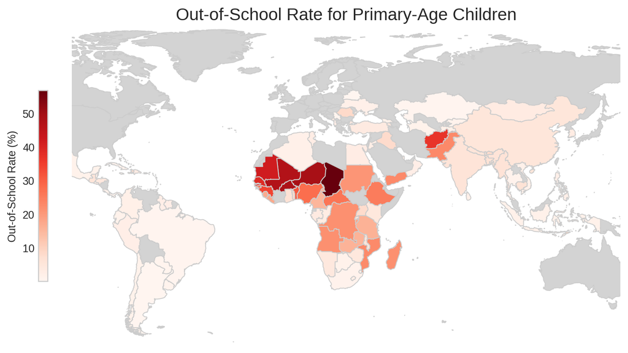

(b)

Figure 1

### 1.2 Regional Analysis of Education Access

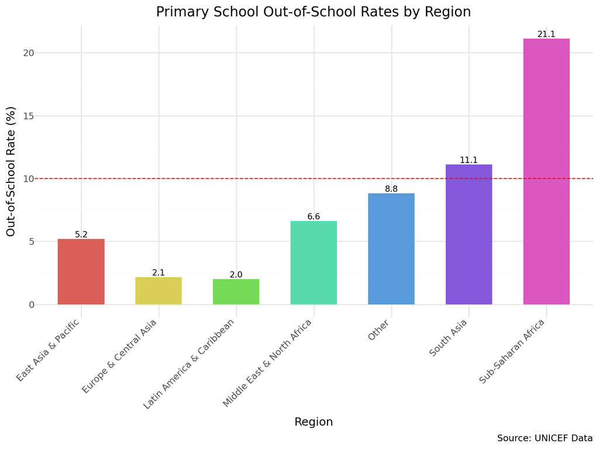

Figure 2: Regional Comparison of Out-of-School Rates for Primary-Age Children

```python
# Create a bar chart comparing regions
p = (ggplot(regional_avg, aes(x='region', y='obs_value', fill='region'))
  + geom_bar(stat='identity', width=0.6)
  + geom_hline(yintercept=global_avg, linetype='dashed', color='red')
  + geom_text(aes(label='round(obs_value, 1)'), va='bottom', size=8)
  + labs(title='Primary School Out-of-School Rates by Region',
      x='Region',
      y='Out-of-School Rate (%)',
      caption='Source: UNICEF Data')
  + theme_minimal()
  + theme(axis_text_x=element_text(angle=45, hjust=1),
      legend_position='none',
      figure_size=(8, 6))  # Added figure_size to control dimensions
)
display(p)
```

In contrast, regions like Europe, Central Asia, and much of Latin America have achieved near-universal primary education, with out-of-school rates below 5%. These regional differences highlight the need for targeted interventions in areas where education access remains limited.

Gender analysis (not shown in the visualization) indicates that in many countries, girls remain more likely to be out of school than boys, particularly in regions with the highest overall out-of-school rates.

## 2 Global Analysis of HPV Vaccination

```python
# Prepare vaccination data
# Filter for the most recent data for each country
vaccination_latest = vaccination_data.sort_values('time_period', ascending=False).drop_duplicates('country')

# Add region to vaccination data
vaccination_latest['region'] = vaccination_latest['country'].apply(assign_region)

# Calculate regional averages for vaccination
regional_vax_avg = vaccination_latest.groupby('region')['obs_value'].mean().reset_index()
regional_vax_avg = regional_vax_avg.sort_values('obs_value', ascending=False)

# Time series analysis for selected countries with good data coverage
countries_for_timeseries = ['Australia', 'Canada', 'Brazil', 'France', 'Iceland', 'Rwanda', 'South Africa']
vaccination_timeseries = vaccination_data[vaccination_data['country'].isin(countries_for_timeseries)]

# Prepare data for map visualization
vax_map_data = pd.merge(vaccination_latest[['country', 'obs_value']],
                        world[['name', 'geometry']],
                        how='right',
                        left_on='country',
                        right_on='name')

# For correlation analysis, merge education and vaccination data
merged_indicators = pd.merge(education_latest[['country', 'obs_value', 'region']],
                            vaccination_latest[['country', 'obs_value']],
                            on='country',
                            suffixes=('_education', '_vaccination'))
```

### 2.1 Global Map of HPV Vaccination Coverage

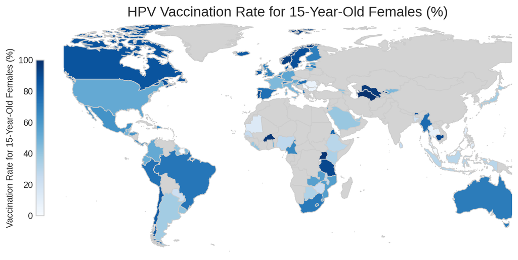

Figure 3: Global Distribution of HPV Vaccination Coverage Among 15-Year-Old Females

```python
# Merge map with vaccination data
vax_merged = world.merge(vaccination_latest, how='left', left_on='name', right_on='country')

# Plot map
fig, ax = plt.subplots(1, 1, figsize=(10, 8))
vax_merged.plot(column='obs_value',
               cmap='Blues',
               linewidth=0.8,
               ax=ax,
               edgecolor='0.8',
               legend=True,
               legend_kwds={'shrink': 0.4, 'aspect': 20, 'label': 'Vaccination Rate for 15-Year-Old Females (%)',   'fraction': 0.046, 'pad': 0.04, 'location': 'left'},
               missing_kwds={"color": "lightgrey", "label": "No data"})

ax.set_title('HPV Vaccination Rate for 15-Year-Old Females (%)', fontdict={'fontsize': 16})

ax.set_xlim([-130, 150])  # Crop more from the left side
ax.set_ylim([-60, 85])    # Adjust vertical limits to focus on populated areas

ax.axis('off')
plt.show()
```

### 2.2 Trends in HPV Vaccination Over Time

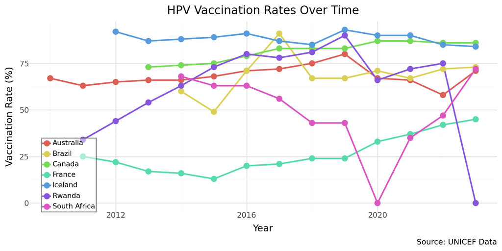

Figure 4: Trends in HPV Vaccination Rates in Selected Countries (2010-2023)

```python
# Create time series plot
p = (ggplot(vaccination_timeseries, aes(x='time_period', y='obs_value', color='country', group='country'))
  + geom_line(size=1)
  + geom_point(size=3)
  + labs(title='HPV Vaccination Rates Over Time',
      x='Year',
      y='Vaccination Rate (%)',
      caption='Source: UNICEF Data')
  + theme_minimal()
  + theme(legend_title=element_blank(),
       legend_position=(0.03, 0.0),  # Position legend inside plot at bottom left
       legend_background=element_rect(fill='white', alpha=0.5),  # Add semi-transparent background
       legend_box_margin=0,
       legend_key_size=6,  # Make legend keys smaller
       legend_text=element_text(size=8),  # Reduce the legend text size
       figure_size=(8, 4))
    )
display(p)
```

### 2.3 Countries with Highest and Lowest HPV Vaccination Rates

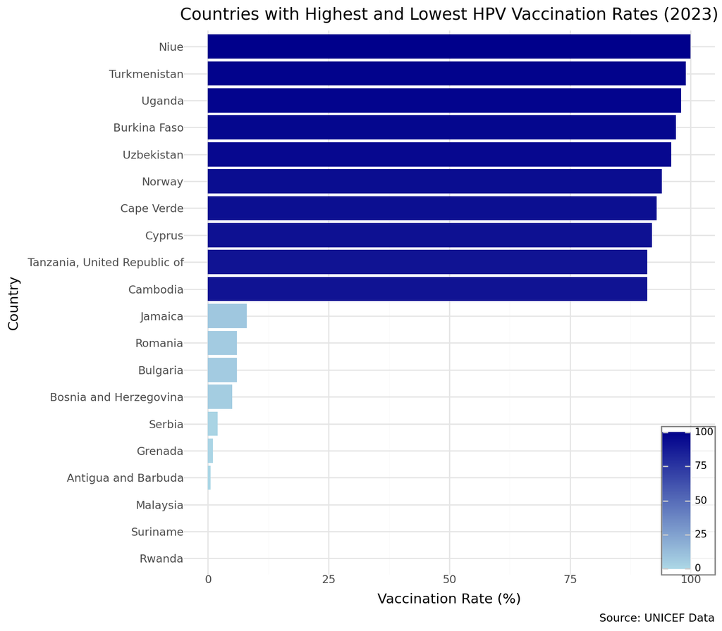

Figure 5: Countries with Highest and Lowest HPV Vaccination Rates (2023 data)

```python
# Get 2023 data only
vax_2023 = vaccination_data[vaccination_data['time_period'] == 2023].copy()

# Find top and bottom 15 countries
top_countries = vax_2023.sort_values('obs_value', ascending=False).head(10)
bottom_countries = vax_2023.sort_values('obs_value').head(10)
countries_to_plot = pd.concat([top_countries, bottom_countries])

# Create bar chart
p = (ggplot(countries_to_plot, aes(x='reorder(country, obs_value)', y='obs_value', fill='obs_value'))
     + geom_bar(stat='identity')
     + scale_fill_gradient(low='lightblue', high='darkblue')
     + coord_flip()
     + labs(title='Countries with Highest and Lowest HPV Vaccination Rates (2023)',
            x='Country',
            y='Vaccination Rate (%)',
            caption='Source: UNICEF Data')
     + theme_minimal()
     + theme(legend_title=element_blank(),
      legend_position=(1.0, 0.0),  # Position legend inside plot at bottom right
       legend_background=element_rect(fill='white', alpha=0.5),  # Add semi-transparent background
       legend_box_margin=0,
       legend_key_size=15,  # Make legend keys smaller
       legend_text=element_text(size=8),  # Reduce the legend text size
       figure_size=(8, 7))
    )
display(p)
```

Time trend analysis shows that while some countries have maintained consistently high vaccination rates, others have experienced fluctuations. The COVID-19 pandemic (2020-2022) caused visible drops in vaccination rates in several countries, highlighting the vulnerability of preventive healthcare programs during global crises.

Regional patterns in HPV vaccination do not always mirror those seen in education access. Some regions with moderate education outcomes have achieved high vaccination rates through targeted healthcare initiatives.

## 3 Relationship Between Education and Healthcare Indicators

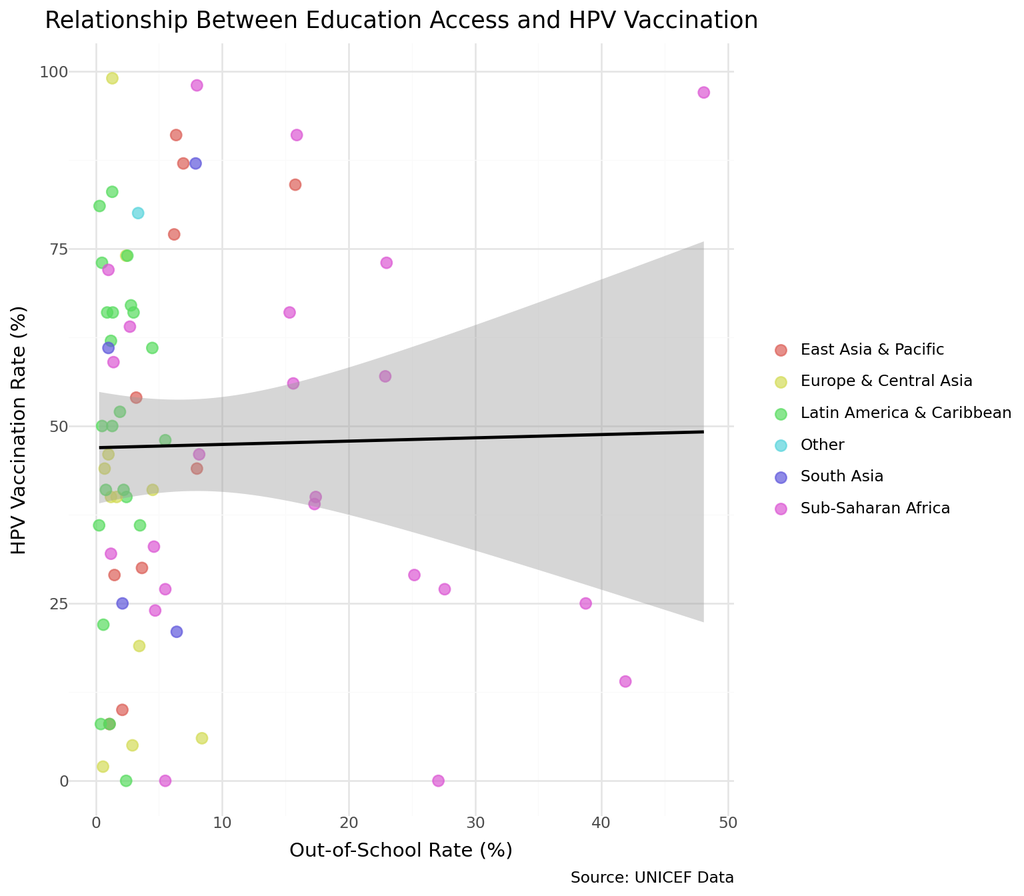

Figure 6: Relationship Between Primary School Out-of-School Rate and HPV Vaccination Coverage

```
Correlation coefficient: 0.02
```

```python
# Create scatter plot with regression line
p = (ggplot(merged_indicators, aes(x='obs_value_education', y='obs_value_vaccination', color='region'))
     + geom_point(size=3, alpha=0.7)
     + geom_smooth(method='lm', color='black', se=True)
     + labs(title='Relationship Between Education Access and HPV Vaccination',
            x='Out-of-School Rate (%)',
            y='HPV Vaccination Rate (%)',
            caption='Source: UNICEF Data')
     + theme_minimal()
     + theme(legend_title=element_blank(),
    figure_size=(8, 7))  # Reduced width from default to 6 inches
    )
display(p)

# Calculate correlation coefficient
corr = merged_indicators['obs_value_education'].corr(merged_indicators['obs_value_vaccination'])
print(f"Correlation coefficient: {corr:.2f}")
```

Regional clustering is also evident, with countries from the same region often showing similar patterns in both indicators.

## 4 Conclusions and Recommendations

Based on these findings, we recommend:

- **Targeted education interventions** in countries with the highest out-of-school rates, with particular attention to addressing gender disparities where they exist.
- **Expansion of HPV vaccination programs** in regions with low coverage, building on successful models from countries that have achieved high rates.
- **Integrated approaches** that address education and healthcare simultaneously, recognizing the interconnected nature of these development indicators.
- **Strengthened data collection systems** to monitor progress and identify emerging challenges, particularly in countries with limited current data availability.

As UNICEF continues to work toward ensuring every child’s right to education and healthcare, these data-driven insights can help guide resource allocation and program design for maximum impact.

## 5 Appendix: Data Sources and Methodology

This report analyzes two key datasets from UNICEF:

1. **Out-of-school rate for children of primary school age**: This indicator measures the percentage of children in the official primary school age range who are not enrolled in either primary or secondary education.
2. **Percentage of females who received the last dose of human papillomavirus (HPV) vaccine per national schedule**: This tracks the completion of the HPV vaccination series among 15-year-old females.

The data visualization and analysis were conducted using Python, with the plotnine, GeoPandas, and scikit-learn libraries. Regional aggregations were calculated as unweighted averages of country-level indicators.

Limitations of this analysis include incomplete data coverage for some countries and potential variations in data collection methodologies across different national statistical systems.